[figure not shown]

# ĐỒ ÁN

## PHÂN TÍCH CÁC YẾU TỐ ẢNH HƯỞNG ĐẾN KẾT QUẢ HỌC TẬP

#### Họ và tên: Nguyễn Ngọc Hiếu

#### MSSV: 3122411055

#### Lớp: DCT122C5

#### GVHD: Phan Tuấn Đăng

## Công việc 1: Khám phá và xử lý dữ liệu

- Tải và đọc dữ liệu bằng pandas
- Phân tích cơ bản: Kiểm tra giá trị thiếu và xử lý (ví dụ thay bằng trung bình hoặc loại bỏ)
- Báo cáo ngắn về đặc điểm dữ liệu: số bản ghi, phân phối G3, studytime, v.v

### Tải và đọc dữ liệu bằng pandas

```python
import pandas as pd
df = pd.read_csv("student-mat.csv", sep=";")
df.head(10)
```

|  | school | sex | age | address | famsize | Pstatus | Medu | Fedu | Mjob | Fjob | ... | famrel | freetime | goout | Dalc | Walc | health | absences | G1 | G2 | G3 |
| --- | --- | --- | --- | --- | --- | --- | --- | --- | --- | --- | --- | --- | --- | --- | --- | --- | --- | --- | --- | --- | --- |
| 0 | GP | F | 18 | U | GT3 | A | 4 | 4 | at_home | teacher | ... | 4 | 3 | 4 | 1 | 1 | 3 | 6 | 5 | 6 | 6 |
| 1 | GP | F | 17 | U | GT3 | T | 1 | 1 | at_home | other | ... | 5 | 3 | 3 | 1 | 1 | 3 | 4 | 5 | 5 | 6 |
| 2 | GP | F | 15 | U | LE3 | T | 1 | 1 | at_home | other | ... | 4 | 3 | 2 | 2 | 3 | 3 | 10 | 7 | 8 | 10 |
| 3 | GP | F | 15 | U | GT3 | T | 4 | 2 | health | services | ... | 3 | 2 | 2 | 1 | 1 | 5 | 2 | 15 | 14 | 15 |
| 4 | GP | F | 16 | U | GT3 | T | 3 | 3 | other | other | ... | 4 | 3 | 2 | 1 | 2 | 5 | 4 | 6 | 10 | 10 |
| 5 | GP | M | 16 | U | LE3 | T | 4 | 3 | services | other | ... | 5 | 4 | 2 | 1 | 2 | 5 | 10 | 15 | 15 | 15 |
| 6 | GP | M | 16 | U | LE3 | T | 2 | 2 | other | other | ... | 4 | 4 | 4 | 1 | 1 | 3 | 0 | 12 | 12 | 11 |
| 7 | GP | F | 17 | U | GT3 | A | 4 | 4 | other | teacher | ... | 4 | 1 | 4 | 1 | 1 | 1 | 6 | 6 | 5 | 6 |
| 8 | GP | M | 15 | U | LE3 | A | 3 | 2 | services | other | ... | 4 | 2 | 2 | 1 | 1 | 1 | 0 | 16 | 18 | 19 |
| 9 | GP | M | 15 | U | GT3 | T | 3 | 4 | other | other | ... | 5 | 5 | 1 | 1 | 1 | 5 | 0 | 14 | 15 | 15 |

10 rows × 33 columns

### Phân tích cơ bản

```python
# Thống kê dữ liệu nhanh
df.info()
df.describe()
```

```
<class 'pandas.core.frame.DataFrame'>
RangeIndex: 395 entries, 0 to 394
Data columns (total 33 columns):
 #   Column      Non-Null Count  Dtype
---  ------      --------------  -----
 0   school      395 non-null    object
 1   sex         395 non-null    object
 2   age         395 non-null    int64
 3   address     395 non-null    object
 4   famsize     395 non-null    object
 5   Pstatus     395 non-null    object
 6   Medu        395 non-null    int64
 7   Fedu        395 non-null    int64
 8   Mjob        395 non-null    object
 9   Fjob        395 non-null    object
```

[output cut: 25 more lines]

|  | age | Medu | Fedu | traveltime | studytime | failures | famrel | freetime | goout | Dalc | Walc | health | absences | G1 | G2 | G3 |
| --- | --- | --- | --- | --- | --- | --- | --- | --- | --- | --- | --- | --- | --- | --- | --- | --- |
| count | 395.000000 | 395.000000 | 395.000000 | 395.000000 | 395.000000 | 395.000000 | 395.000000 | 395.000000 | 395.000000 | 395.000000 | 395.000000 | 395.000000 | 395.000000 | 395.000000 | 395.000000 | 395.000000 |
| mean | 16.696203 | 2.749367 | 2.521519 | 1.448101 | 2.035443 | 0.334177 | 3.944304 | 3.235443 | 3.108861 | 1.481013 | 2.291139 | 3.554430 | 5.708861 | 10.908861 | 10.713924 | 10.415190 |
| std | 1.276043 | 1.094735 | 1.088201 | 0.697505 | 0.839240 | 0.743651 | 0.896659 | 0.998862 | 1.113278 | 0.890741 | 1.287897 | 1.390303 | 8.003096 | 3.319195 | 3.761505 | 4.581443 |
| min | 15.000000 | 0.000000 | 0.000000 | 1.000000 | 1.000000 | 0.000000 | 1.000000 | 1.000000 | 1.000000 | 1.000000 | 1.000000 | 1.000000 | 0.000000 | 3.000000 | 0.000000 | 0.000000 |
| 25% | 16.000000 | 2.000000 | 2.000000 | 1.000000 | 1.000000 | 0.000000 | 4.000000 | 3.000000 | 2.000000 | 1.000000 | 1.000000 | 3.000000 | 0.000000 | 8.000000 | 9.000000 | 8.000000 |
| 50% | 17.000000 | 3.000000 | 2.000000 | 1.000000 | 2.000000 | 0.000000 | 4.000000 | 3.000000 | 3.000000 | 1.000000 | 2.000000 | 4.000000 | 4.000000 | 11.000000 | 11.000000 | 11.000000 |
| 75% | 18.000000 | 4.000000 | 3.000000 | 2.000000 | 2.000000 | 0.000000 | 5.000000 | 4.000000 | 4.000000 | 2.000000 | 3.000000 | 5.000000 | 8.000000 | 13.000000 | 13.000000 | 14.000000 |
| max | 22.000000 | 4.000000 | 4.000000 | 4.000000 | 4.000000 | 3.000000 | 5.000000 | 5.000000 | 5.000000 | 5.000000 | 5.000000 | 5.000000 | 75.000000 | 19.000000 | 19.000000 | 20.000000 |

**Phân tích qua `df.info()` và `df.describe()`**

`df.info()` cho ta biết được về tổng quan dữ liệu:

- Số cột: 33 cột
- Số dòng: 395 dòng
- Kiểu dữ liệu:
  - 16 cột là kiểu số (int64) – dữ liệu định lượng
  - 17 cột là kiểu object – thường là dữ liệu dạng chuỗi hoặc phân loại (categorical)
1. Biến định lượng (số) int64 (16 cột)

| Cột | Ý nghĩa ngắn |
| --- | --- |
| `age` | Tuổi học sinh |
| `Medu` | Trình độ học vấn mẹ (0–4) |
| `Fedu` | Trình độ học vấn cha (0–4) |
| `traveltime` | Thời gian đến trường |
| `studytime` | Thời gian học mỗi tuần |
| `failures` | Số môn học sinh bị trượt |
| `famrel`, `freetime`, `goout` | Quan hệ gia đình, thời gian rảnh, ra ngoài |
| `Dalc`, `Walc` | Mức uống rượu trong tuần và cuối tuần |
| `health` | Sức khỏe tự đánh giá (1-5) |
| `absences` | Số buổi nghỉ học |
| `G1`, `G2`, `G3` | Điểm học kỳ 1, 2 và điểm cuối (0–20) |

2. Biến phân loại (danh mục) object (17 cột)

| Cột | Ý nghĩa |
| --- | --- |
| `school` | Trường học (GP hoặc MS) |
| `sex` | Giới tính (F/M) |
| `address` | Địa chỉ (U = đô thị, R = nông thôn) |
| `famsize` | Quy mô gia đình (LE3 = ≤3, GT3 = >3) |
| `Pstatus` | Tình trạng sống với phụ huynh (T = cùng, A = riêng) |
| `Mjob`, `Fjob` | Nghề nghiệp của mẹ và cha |
| `reason` | Lý do chọn trường (gần nhà, danh tiếng,...) |
| `guardian` | Người giám hộ (mẹ, cha, người khác) |
| `schoolsup`, `famsup`, `paid`, `activities`, `nursery`, `higher`, `internet`, `romantic` | Hỗ trợ học tập, hoạt động, mối quan hệ,... |

`df.describe()` cho ta biết được về tổng quan dữ liệu thuộc kiểu dữ liệu số (int hoặc float):

1. Tổng quan dữ liệu
- Số học sinh: 395
- Bao gồm 16 biến số học sinh, tất cả đều là dữ liệu số (int hoặc float).
2. Phân tích từng nhóm thuộc tính
- Đặc điểm cá nhân:

| Biến | Ý nghĩa | Min – Max | Trung bình | Nhận xét |
| --- | --- | --- | --- | --- |
| `age` | Tuổi học sinh | 15 – 22 | 16.7 | Tập trung ở tuổi THPT |
| `Medu` | Trình độ học vấn mẹ (0–4) | 0 – 4 | 2.75 | Mẹ phần lớn học cấp 2–3 |
| `Fedu` | Trình độ học vấn cha (0–4) | 0 – 4 | 2.52 | Cha thấp hơn mẹ một chút |

- Thời gian và nỗ lực học:

| Biến | Ý nghĩa | Min – Max | Trung bình | Nhận xét |
| --- | --- | --- | --- | --- |
| `traveltime` | Thời gian đến trường (1–4) | 1 – 4 | 1.45 | Đa số học sinh gần trường |
| `studytime` | Thời gian học/tuần (1–4) | 1 – 4 | 2.03 | Chủ yếu học < 5h/tuần |
| `failures` | Số môn học sinh trượt (0–3) | 0 – 3 | 0.33 | Hầu hết không bị trượt |

- Cuộc sống cá nhân & xã hội:

| Biến | Ý nghĩa | Trung bình | Nhận xét ngắn |
| --- | --- | --- | --- |
| `famrel` | Quan hệ gia đình (1–5) | 3.94 | Phần lớn tốt |
| `freetime` | Thời gian rảnh (1–5) | 3.24 | Ổn định |
| `goout` | Tần suất ra ngoài với bạn bè | 3.11 | Cân bằng |
| `Dalc` | Mức độ uống rượu trong tuần | 1.48 | Thấp |
| `Walc` | Mức độ uống rượu cuối tuần | 2.29 | Hơi cao hơn |
| `health` | Tình trạng sức khoẻ (1–5) | 3.55 | Tốt |
| `absences` | Số buổi nghỉ học | 0 – 75 | 5.7 buổi |

Chú ý: Có học sinh nghỉ tới 75 buổi → cần kiểm tra dữ liệu ngoại lệ.

- Kết quả học tập;

| Biến | Ý nghĩa | Min – Max | Trung bình | Nhận xét |
| --- | --- | --- | --- | --- |
| `G1` | Điểm kỳ 1 (0–20) | 3 – 19 | 10.91 | Trung bình |
| `G2` | Điểm kỳ 2 (0–20) | 0 – 19 | 10.71 | Khá ổn |
| `G3` | Điểm cuối kỳ (0–20) | 0 – 20 | 10.42 | Có giảm nhẹ so với G1, G2 |

```python
# Kiểm tra các giá trị thiếu của từng cột
# In ra các cột bị thiếu và số lượng giá trị thiếu trong từng cột.
missing = df.isnull().sum()
print("Thiếu dữ liệu:\n", missing[missing > 0])
```

```
Thiếu dữ liệu:
 Series([], dtype: int64)
```

**Kết luận:** Không có dữ liệu nào bị thiếu

```python
# Thay bằng trung bình
# Ta sẽ thay các giá trị bị thiếu (NaN) trong cột cot_na bằng giá trị trung bình của chính cột đó.
# giả sử studytime là cột có giá trị bị thiếu

df['age'] = df['age'].fillna(df['age'].mean())
```

**Kết luận:** Ví dụ: cột age có dòng thiếu giá trị null hoặc NaN thì sẽ dùng lệnh `df['age'] = df['age'].fillna(df['age'].mean())`

### Báo cáo ngắn về đặc điểm dữ liệu

```python
# Trả về số bản ghi trong Data Frame tương ứng với số lượng học sinh trong tập dữ liệu
print("Số bản ghi:", len(df))


print("Phân phối G3:")
print(df['G3'].value_counts().sort_index())
print()

print("Phân phối studytime:")
print(df['studytime'].value_counts().sort_index())
print()

print("Phân phối school:")
print(df['school'].value_counts().sort_index())
print()

print("Phân phối sex:")
print(df['sex'].value_counts().sort_index())
print()
```

```
Số bản ghi: 395
Phân phối G3:
G3
0     38
4      1
5      7
6     15
7      9
8     32
9     28
10    56
11    47
12    31
13    31
14    27
15    33
16    16
17     6
18    12
19     5
20     1
Name: count, dtype: int64

Phân phối studytime:
studytime
1    105
2    198
3     65
4     27
Name: count, dtype: int64

Phân phối school:
school
GP    349
MS     46
Name: count, dtype: int64

Phân phối sex:
sex
F    208
M    187
Name: count, dtype: int64
```

**Kết luận:**

**1. Tổng quan về phân tích:**

- Số học sinh: 395
- Số cột phân tích: 4 (`G3`, `studytime`, `school`, `sex`)

**2. Phân phối điểm cuối kỳ (`G3`)**

- G3 dao động từ 0 đến 20, là điểm tổng kết môn học.
- Một số mốc đáng chú ý:
  - Điểm cao nhất: 20 (1 học sinh)
  - Điểm thấp nhất: 0 (38 học sinh → rất đáng chú ý)
  - Điểm phổ biến nhất: 10 (56 học sinh), 11 (47 học sinh)
- G3 có xu hướng tập trung quanh điểm 10–15, nhưng có nhiều học sinh điểm rất thấp (0) → cần điều tra thêm.

**3. Phân phối thời gian học mỗi tuần (`studytime`)**

| Giá trị | Ý nghĩa | Số lượng học sinh |
| --- | --- | --- |
| 1 | < 2 giờ/tuần | 105 |
| 2 | 2–5 giờ/tuần | 198 |
| 3 | 5–10 giờ/tuần | 65 |
| 4 | > 10 giờ/tuần | 27 |

→ Phần lớn học sinh (**76%**) học dưới *5 giờ/tuần*.

→ Chỉ 27 học sinh dành hơn 10 giờ/tuần để học → tiềm năng so sánh với điểm G3.

**4. Phân phối trường học (`school`)**

| Trường | Số lượng học sinh |
| --- | --- |
| GP | 349 |
| MS | 46 |

→ Trường GP chiếm **~88%** dữ liệu, MS chỉ có **12%** → có thể ảnh hưởng đến phân tích nếu không cân bằng.

**5. Phân phối trường học (`sex`)**

| Giới tính | Số lượng |
| --- | --- |
| Nữ (F) | 208 |
| Nam (M) | 187 |

→ Tương đối cân bằng giữa nam và nữ (**53%** nữ, **47%** nam).

## Công việc 2: Trực quan hoá dữ liệu

- **Matplotlib:**
  - Biểu đồ cột: Số học sinh theo studytime.
  - Biểu đồ phân tán: studytime vs G3, với màu sắc khác nhau cho nam (sex = 'M') và nữ (sex = 'F').
- **Seaborn:**
  - lmplot: studytime và G3, với hue='sex'.
  - boxplot: Phân phối G3 theo studytime.
  - pairplot: Mối quan hệ giữa G1, G2, G3, studytime.
- **Bokeh:**
  - Biểu đồ phân tán tương tác: studytime và G3, với HoverTool hiện thị age, sex, absences.
  - Row Layout: (1) Biểu đồ cột cho studytime, (2) Biểu đồ phân tán như trên.
  - Tính năng ẩn/hiện cho nam và nữ trong biểu đồ phân tán.
- **Yêu cầu:** Vẽ ít nhất 3 biểu đồ (một từ mỗi thư hiện) với tiêu đề, nhãn trục, màu sắc, chú thích. Thêm slider widget trong Bokeh để lọc studytime và cập nhật biểu đồ

### Matplotlib:

- Biểu đồ cột: Số học sinh theo studytime.
- Biểu đồ phân tán: studytime vs G3, với màu sắc khác nhau cho nam (sex = 'M') và nữ (sex = 'F').

#### Biểu đồ cột: Số học sinh theo studytime

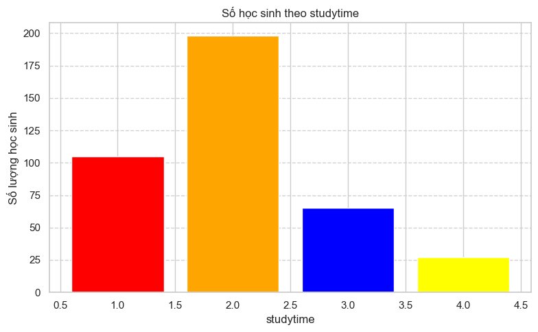

```python
import matplotlib.pyplot as plt

# Biểu đồ cột số học sinh theo studytime
bar_plot_studytime = df['studytime'].value_counts().sort_index()

# Vẽ biểu đồ cột số học sinh theo studytime
plt.figure(figsize=(8, 5))
plt.bar(bar_plot_studytime.index, bar_plot_studytime.values, color=['red', 'orange', 'blue', 'yellow'])
plt.title('Số học sinh theo studytime')
plt.xlabel('studytime')
plt.ylabel('Số lượng học sinh')
plt.grid(axis='y', linestyle='--', alpha=0.9)
plt.tight_layout()
plt.show()
```

#### Biểu đồ phân tán: studytime vs G3, với màu sắc khác nhau cho nam (sex = 'M') và nữ (sex = 'F')

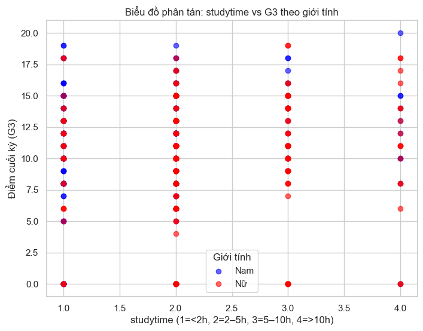

```python
# Tách dữ liệu theo giới tính
male = df[df['sex'] == 'M']
female = df[df['sex'] == 'F']

# Tạo biểu đồ
plt.figure(figsize=(8, 6))
# Vẽ dữ liệu nam
plt.scatter(male['studytime'], male['G3'], color='blue', label='Nam', alpha=0.6)
# Vẽ dữ liệu nữ
plt.scatter(female['studytime'], female['G3'], color='red', label='Nữ', alpha=0.6)

# Thiết lập tiêu đề và nhãn
plt.title('Biểu đồ phân tán: studytime vs G3 theo giới tính')
plt.xlabel('studytime (1=<2h, 2=2–5h, 3=5–10h, 4=>10h)')
plt.ylabel('Điểm cuối kỳ (G3)')
plt.legend(title='Giới tính')


# Hiển thị biểu đồ
plt.show()
```

### Seaborn

- lmplot: studytime và G3, với hue='sex'.
- boxplot: Phân phối G3 theo studytime.
- pairplot: Mối quan hệ giữa G1, G2, G3, studytime.

#### lmplot: studytime và G3, với hue='sex'

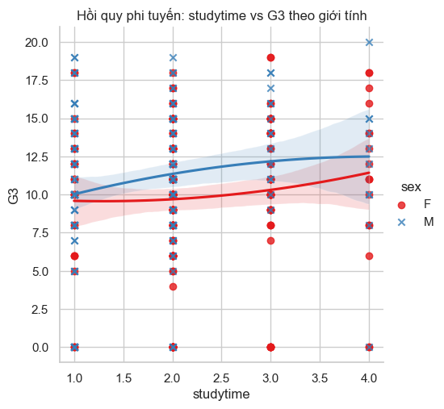

```python
import seaborn as sns

# Tạo thêm cột studytime^2 vào DataFrame

df['studytime_sq'] = df['studytime'] ** 2

# Dùng lmplot với biến mới (đa thức bậc 2)
# Dùng order=2 để vẽ đường hồi quy bậc hai (parabol), tức là phi tuyến để xác định rõ hơn
sns.lmplot(x='studytime', y='G3', data=df, hue='sex', order=2, markers=["o", "x"], palette='Set1')

plt.title('Hồi quy phi tuyến: studytime vs G3 theo giới tính')
plt.show()
```

#### boxplot: Phân phối G3 theo studytime.

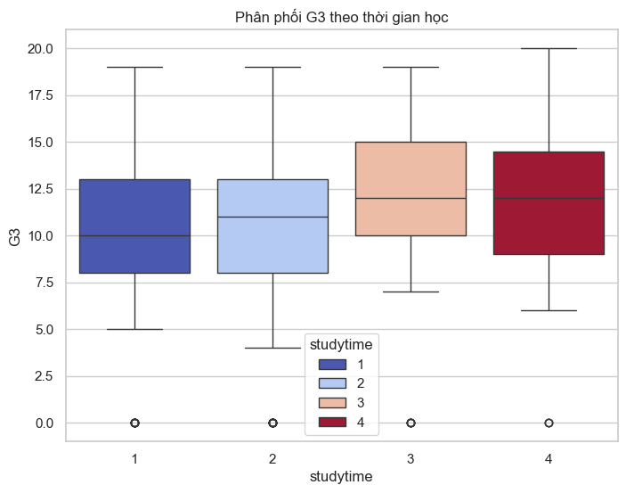

```python
plt.figure(figsize=(8, 6))
sns.boxplot(x='studytime', y='G3', hue='studytime', data=df,
            palette="coolwarm", legend=True)
plt.title("Phân phối G3 theo thời gian học")
plt.show()
```

#### pairplot: Mối quan hệ giữa G1, G2, G3, studytime.

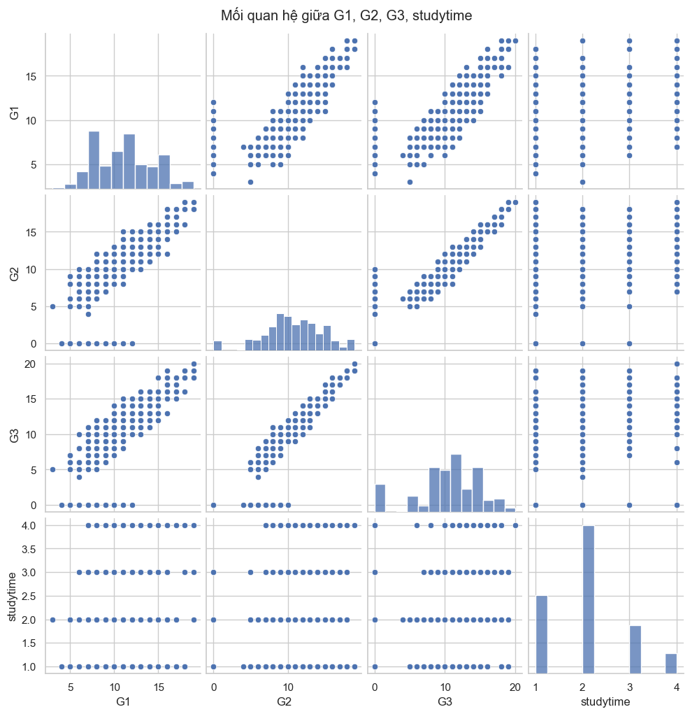

```python
sns.pairplot(df[['G1', 'G2', 'G3', 'studytime']], height=2.5)
plt.suptitle('Mối quan hệ giữa G1, G2, G3, studytime', y=1.02)
plt.show()
```

### Bokeh:

- Biểu đồ phân tán tương tác: studytime và G3, với HoverTool hiện thị age, sex, absences.
- Row Layout: (1) Biểu đồ cột cho studytime, (2) Biểu đồ phân tán như trên.
- Tính năng ẩn/hiện cho nam và nữ trong biểu đồ phân tán.

#### Biểu đồ phân tán tương tác: studytime và G3, với HoverTool hiện thị age, sex, absences.

```python
import pandas as pd
from bokeh.plotting import figure, show
from bokeh.models import HoverTool, ColumnDataSource
from bokeh.io import output_notebook

# Chuẩn bị dữ liệu cho Bokeh
source = ColumnDataSource(data={
    'studytime': df['studytime'],
    'G3': df['G3'],
    'age': df['age'],
    'sex': df['sex'],
    'absences': df['absences']
})

# Tạo biểu đồ phân tán
p = figure(title="Biểu đồ phân tán: studytime vs G3",
           x_axis_label='Thời gian học (studytime)',
           y_axis_label='Điểm G3',
           width=800, height=400)

# Vẽ điểm phân tán
p.scatter('studytime', 'G3', source=source, size=10, color='navy', alpha=0.5)

# Thêm HoverTool
hover = HoverTool(tooltips=[
    ("Tuổi", "@age"),
    ("Giới tính", "@sex"),
    ("Số ngày nghỉ", "@absences")
])
p.add_tools(hover)

# Tùy chỉnh giao diện
p.title.text_font_size = '14pt'
p.xaxis.axis_label_text_font_size = '12pt'
p.yaxis.axis_label_text_font_size = '12pt'
p.grid.grid_line_color = 'gray'
p.grid.grid_line_alpha = 0.3

# Hiển thị biểu đồ
output_notebook()
show(p)
```

Loading BokehJS ...

#### Row Layout: (1) Biểu đồ cột cho studytime, (2) Biểu đồ phân tán như trên.

```python
from bokeh.plotting import figure, show
from bokeh.models import HoverTool, ColumnDataSource
from bokeh.layouts import row
from bokeh.io import output_notebook

# Chuẩn bị dữ liệu cho Bokeh
source = ColumnDataSource(data={
    'studytime': df['studytime'],
    'G3': df['G3'],
    'age': df['age'],
    'sex': df['sex'],
    'absences': df['absences']
})

# Chuẩn bị dữ liệu cho biểu đồ phân tán
source_scatter = ColumnDataSource(data={
    'studytime': df['studytime'],
    'G3': df['G3'],
    'age': df['age'],
    'sex': df['sex'],
    'absences': df['absences']
})

# Chuẩn bị dữ liệu cho biểu đồ cột
source_bar = ColumnDataSource(data={
    'studytime': df['studytime'].value_counts().index,
    'count': df['studytime'].value_counts().values
})

# Tạo biểu đồ cột (Bar Chart)
p1 = figure(title="Số lượng học sinh theo studytime",
            x_axis_label='Thời gian học (studytime)',
            y_axis_label='Số lượng',
            width=400, height=400)
p1.vbar(x='studytime', top='count', source=source_bar, width=0.5, color='teal')
p1.xaxis.ticker = [1, 2, 3, 4]  # Đảm bảo trục x chỉ hiển thị các giá trị 1, 2, 3, 4
p1.title.text_font_size = '14pt'
p1.xaxis.axis_label_text_font_size = '12pt'
p1.yaxis.axis_label_text_font_size = '12pt'
p1.grid.grid_line_color = 'gray'
p1.grid.grid_line_alpha = 0.3

# Tạo biểu đồ phân tán
p2 = figure(title="Biểu đồ phân tán: studytime vs G3",
            x_axis_label='Thời gian học (studytime)',
            y_axis_label='Điểm G3',
            width=400, height=400)  # Điều chỉnh width để vừa với row layout

p2.scatter('studytime', 'G3', source=source_scatter, size=10, color='navy', alpha=0.5)

# Thêm HoverTool
hover = HoverTool(tooltips=[
    ("Tuổi", "@age"),
    ("Giới tính", "@sex"),
    ("Số ngày nghỉ", "@absences")
])
p2.add_tools(hover)

# Tùy chỉnh giao diện
p2.title.text_font_size = '14pt'
p2.xaxis.axis_label_text_font_size = '12pt'
p2.yaxis.axis_label_text_font_size = '12pt'
p2.grid.grid_line_color = 'gray'
p2.grid.grid_line_alpha = 0.3

# Tạo Row Layout
layout = row(p1, p2)

# Hiển thị biểu đồ
output_notebook()
show(layout)
```

Loading BokehJS ...

#### Tính năng ẩn/hiện cho nam và nữ trong biểu đồ phân tán.

```python
from bokeh.plotting import figure, show
from bokeh.models import HoverTool, ColumnDataSource, CheckboxGroup, CustomJS, Legend
from bokeh.layouts import row, column
from bokeh.io import output_notebook

output_notebook()

# Chuẩn bị dữ liệu
source_scatter = ColumnDataSource(data={
    'studytime': df['studytime'],
    'G3': df['G3'],
    'age': df['age'],
    'sex': df['sex'],
    'absences': df['absences']
})

# Tạo figure
p2 = figure(title="Biểu đồ phân tán: studytime vs G3",
            x_axis_label='Thời gian học (studytime)',
            y_axis_label='Điểm G3',
            width=400, height=400)

# Tạo 2 source riêng biệt cho nam và nữ
source_m = ColumnDataSource(df[df['sex'] == 'M'])
source_f = ColumnDataSource(df[df['sex'] == 'F'])

# Scatter cho nam và nữ, có legend_label
scatter_m = p2.scatter('studytime', 'G3', source=source_m, size=10, color='blue', alpha=0.5, legend_label="Nam")
scatter_f = p2.scatter('studytime', 'G3', source=source_f, size=10, color='red', alpha=0.5, legend_label="Nữ")

# HoverTool
hover = HoverTool(tooltips=[
    ("Tuổi", "@age"),
    ("Giới tính", "@sex"),
    ("Số ngày nghỉ", "@absences")
])
p2.add_tools(hover)

# Cài đặt font
p2.title.text_font_size = '14pt'
p2.xaxis.axis_label_text_font_size = '12pt'
p2.yaxis.axis_label_text_font_size = '12pt'
p2.grid.grid_line_color = 'gray'
p2.grid.grid_line_alpha = 0.3

# Cho phép click vào legend để ẩn/hiện
p2.legend.click_policy = "hide"

# Layout
show(p2)
```

Loading BokehJS ...

#### Yêu cầu: Thêm slider widget trong Bokeh để lọc `studytime` và cập nhật biểu đồ.

```python
from bokeh.plotting import figure, show
from bokeh.models import HoverTool, ColumnDataSource, CustomJS, Slider
from bokeh.layouts import row, column
from bokeh.io import output_notebook

output_notebook()

# Tách dữ liệu nam và nữ
df_m = df[df['sex'] == 'M']
df_f = df[df['sex'] == 'F']

source_m_all = ColumnDataSource(df_m)
source_f_all = ColumnDataSource(df_f)

source_m = ColumnDataSource(df_m)
source_f = ColumnDataSource(df_f)

# Tạo biểu đồ cột
source_bar_all = ColumnDataSource(data={
    'studytime': df['studytime'].value_counts().sort_index().index.tolist(),
    'count': df['studytime'].value_counts().sort_index().values.tolist()
})

source_bar = ColumnDataSource(data=source_bar_all.data.copy())

p1 = figure(title="Số lượng học sinh theo studytime", width=400, height=400,
            x_axis_label='Thời gian học', y_axis_label='Số lượng')
p1.vbar(x='studytime', top='count', width=0.5, source=source_bar, color="teal")
p1.xaxis.ticker = [1, 2, 3, 4]

# Tạo biểu đồ scatter với legend
p2 = figure(title="Biểu đồ phân tán: studytime vs G3", width=400, height=400,
            x_axis_label='Thời gian học', y_axis_label='Điểm G3')

scatter_m = p2.scatter('studytime', 'G3', source=source_m, size=10, color='blue', alpha=0.5, legend_label="Nam")
scatter_f = p2.scatter('studytime', 'G3', source=source_f, size=10, color='red', alpha=0.5, legend_label="Nữ")

hover = HoverTool(tooltips=[("Tuổi", "@age"), ("Giới tính", "@sex"), ("Số ngày nghỉ", "@absences")])
p2.add_tools(hover)
p2.legend.click_policy = "hide"

# Slider lọc studytime
slider = Slider(start=0, end=4, value=0, step=1, title="Lọc theo studytime (0: tất cả)")

# Callback JS cho cả scatter và bar chart
callback = CustomJS(args=dict(
    slider=slider,
    source_m_all=source_m_all, source_f_all=source_f_all,
    source_m=source_m, source_f=source_f,
    source_bar=source_bar,
), code="""
    const val = slider.value;

    function filter_source(source_all, source_filtered) {
        const data_all = source_all.data;
        const new_data = {};
        for (const key in data_all) {
            new_data[key] = [];
        }
        for (let i = 0; i < data_all['studytime'].length; i++) {
            if (val === 0 || data_all['studytime'][i] === val) {
                for (const key in data_all) {
                    new_data[key].push(data_all[key][i]);
                }
            }
        }
        source_filtered.data = new_data;
        source_filtered.change.emit();
    }

    filter_source(source_m_all, source_m);
    filter_source(source_f_all, source_f);

    // Tính lại dữ liệu cho biểu đồ cột
    const all_data = source_m.data.studytime.concat(source_f.data.studytime);
    const counts = {1: 0, 2: 0, 3: 0, 4: 0};
    for (let i = 0; i < all_data.length; i++) {
        counts[all_data[i]] += 1;
    }

    source_bar.data = {
        studytime: [1, 2, 3, 4],
        count: [counts[1], counts[2], counts[3], counts[4]]
    };
    source_bar.change.emit();
""")

slider.js_on_change('value', callback)

# Bố cục
layout = column(slider, row(p1, p2))
show(layout)
```

Loading BokehJS ...

## Công việc 3: Kiểm định thống kê với giả thuyết

- Thực hiện **ít nhất 2 trong 3 kiểm định** sau:

  a. **t-test**:
  - **Giả thuyết**: "Học sinh có số ngày nghỉ cao (absences > trung bình) thì có trung bình điểm G3 thấp hơn đáng kể so với học sinh có số ngày nghỉ thấp (absences ≤ trung bình)."
  - **Yêu cầu**: Tạo hai nhóm dựa trên trung bình absences, thực hiện t-test, báo cáo p-value và kết luận (α=0.05).

  b. **z-test**:
  - **Giả thuyết**: "Trung bình điểm G3 của học sinh học ít (studytime ≤ 2), thì khác biệt đáng kể so với trung bình điểm kỳ vọng của toàn bộ học sinh (giả định từ trung toàn mẫu)."
  - **Yêu cầu**: Tính trung bình G3 của nhóm studytime ≤ 2, so sánh với trung bình toàn bộ, thực hiện z-test, báo cáo p-value và kết luận.

  c. **Chi-square test:**
  - **Giả thuyết**: "Có mối liên hệ giữa mức thời gian học (studytime) và việc đạt điểm cao (G3 ≥ 12) hay thấp (G3 < 12)."
  - **Yêu cầu**: Tạo biến nhị phân từ G3 (cao ≥ 12, thấp < 12), xây dựng bảng tần số (contingency table) giữa studytime và biến mới, thực hiện chi-square, báo cáo p-value và kết luận.
- **Yêu cầu**:
  - Báo cáo: Mô tả giả thuyết, cách xử lý dữ liệu, kết quả kiểm định (p-value), ý nghĩa thực tiễn (ví dụ: ngày nghỉ ảnh hưởng thế nào đến điểm số?).

### a. t-test:

- **Giả thuyết**: "Học sinh có số ngày nghỉ cao (absences > trung bình) thì có trung bình điểm G3 thấp hơn đáng kể so với học sinh có số ngày nghỉ thấp (absences ≤ trung bình)."
- **Yêu cầu**: Tạo hai nhóm dựa trên trung bình absences, thực hiện t-test, báo cáo p-value và kết luận (α=0.05).

#### Giả thuyết kiểm định

- **H0 (Giả thuyết không)**: Không có sự khác biệt đáng kể về điểm G3 giữa học sinh nghỉ nhiều và nghỉ ít.
- **H1 (Giả thuyết đối):** Học sinh nghỉ nhiều có điểm G3 trung bình thấp hơn đáng kể so với học sinh nghỉ ít.

```python
from scipy.stats import ttest_ind

# Tính trung bình của absences
mean_absences = df['absences'].mean()

# Chia thành hai nhóm
group_high_abs = df[df['absences'] > mean_absences]['G3']  # Nhóm nghỉ cao (> trung bình)
group_low_abs = df[df['absences'] <= mean_absences]['G3']  # Nhóm nghỉ thấp (≤ trung bình)

# Thực hiện t-test (kiểm định hai mẫu độc lập)
# Dùng alternative='greater' vì ta muốn kiểm định nhóm nghỉ nhiều có điểm thấp hơn.
t_stat, p_value = ttest_ind(group_high_abs, group_low_abs, alternative='greater')

# In kết quả
print(f"Trung bình absences: {mean_absences:.2f}")
print(f"Trung bình G3 (nhóm nghỉ cao): {group_high_abs.mean():.2f}")
print(f"Trung bình G3 (nhóm nghỉ thấp): {group_low_abs.mean():.2f}")
print(f"t-statistic: {t_stat:.4f}")
print(f"p-value: {p_value:.4f}")

# Kết luận
alpha = 0.05
if p_value < alpha:
    print("Kết luận: Bác bỏ giả thuyết H0. Có bằng chứng thống kê cho thấy học sinh có số ngày nghỉ cao (absences > trung bình) có trung bình điểm G3 thấp hơn đáng kể so với học sinh có số ngày nghỉ thấp (absences ≤ trung bình).")
else:
    print("Kết luận: Không bác bỏ giả thuyết H0. Không có bằng chứng thống kê đủ mạnh để kết luận rằng học sinh có số ngày nghỉ cao có trung bình điểm G3 thấp hơn đáng kể.")
```

```
Trung bình absences: 5.71
Trung bình G3 (nhóm nghỉ cao): 10.84
Trung bình G3 (nhóm nghỉ thấp): 10.17
t-statistic: 1.3983
p-value: 0.0814
Kết luận: Không bác bỏ giả thuyết H0. Không có bằng chứng thống kê đủ mạnh để kết luận rằng học sinh có số ngày nghỉ cao có trung bình điểm G3 thấp hơn đáng kể.
```

### b. z-test:

- **Giả thuyết**: "Trung bình điểm G3 của học sinh học ít (studytime ≤ 2), thì khác biệt đáng kể so với trung bình điểm kỳ vọng của toàn bộ học sinh (giả định từ trung toàn mẫu)."
- **Yêu cầu**: Tính trung bình G3 của nhóm studytime ≤ 2, so sánh với trung bình toàn bộ, thực hiện z-test, báo cáo p-value và kết luận.

#### Giả thuyết kiểm định

- **H0 (giả thuyết không)**: Trung bình điểm G3 của nhóm studytime ≤ 2 bằng trung bình G3 của toàn bộ mẫu (không có sự khác biệt đáng kể).
- **H1 (giả thuyết đối)**: Trung bình điểm G3 của nhóm studytime ≤ 2 khác biệt đáng kể so với trung bình G3 của toàn bộ mẫu.
- **Giả định một α mặc định** (ví dụ: 0.05) nếu cần kết luận cụ thể, nhưng điều này cần được minh bạch.

```python
from statsmodels.stats.weightstats import ztest
import numpy as np

# Tính trung bình G3 toàn bộ mẫu
mean_G3 = df['G3'].mean()
print(f"Trung bình G3 toàn bộ mẫu: {mean_G3:.2f}")

# Lọc nhóm studytime ≤ 2
group_study_le2 = df[df['studytime'] <= 2]['G3']
mean_study_le2 = group_study_le2.mean()
print(f"Trung bình G3 của nhóm studytime ≤ 2: {mean_study_le2:.2f}")

# Thực hiện z-test
z_stat, p_value = ztest(group_study_le2, value=mean_G3, alternative='two-sided')

# Báo cáo kết quả
print(f"z-test: z-statistic = {z_stat:.4f}, p-value = {p_value:.4f}")

# Kết luận
alpha = 0.05
if p_value < alpha:
    print("Kết luận: Bác bỏ H0, trung bình G3 của nhóm studytime ≤ 2 khác biệt đáng kể so với trung bình toàn bộ.")
else:
    print("Kết luận: Không bác bỏ H0, không có đủ bằng chứng để nói trung bình G3 của nhóm studytime ≤ 2 khác biệt với trung bình toàn bộ.")
```

```
Trung bình G3 toàn bộ mẫu: 10.42
Trung bình G3 của nhóm studytime ≤ 2: 10.13
z-test: z-statistic = -1.1132, p-value = 0.2656
Kết luận: Không bác bỏ H0, không có đủ bằng chứng để nói trung bình G3 của nhóm studytime ≤ 2 khác biệt với trung bình toàn bộ.
```

## Task 4: Phân tích và báo cáo

- Viết báo cáo với các nội dung sau:
  - **Phần 1**: Giới thiệu tập dữ liệu, lý do chọn file, mục tiêu phân tích.
  - **Phần 2**: Mô tả cách tạo 3 biểu đồ, lý do chọn, xử lý dữ liệu (nếu có).
  - **Phần 3**: Phân tích xu hướng từ biểu đồ và kết quả kiểm định (với dữ liệu: yếu tố nào ảnh hưởng đến điểm G3?).
  - **Phần 4**: Đề xuất ít nhất 2 cách cải thiện kết quả học tập, dựa trên dữ liệu và kiểm định.

### Phần 1: Giới thiệu tập dữ liệu, lý do chọn file, mục tiêu phân tích

- **Tập dữ liệu**: Sử dụng tập "`student-mat.csv`" từ UCI Machine Learning Repository, chứa thông tin về hiệu suất học tập môn Toán của học sinh (điểm G1, G2, G3, thời gian học - studytime, số ngày nghỉ - absences, giới tính - sex, v.v.).
- **Lý do chọn**: Tập dữ liệu phong phú, có nhiều biến số (33 cột) liên quan đến hoàn cảnh cá nhân, gia đình, và thói quen học tập, phù hợp để phân tích ảnh hưởng đến điểm số. Đồng thời môn toán cũng là một môn yêu thích của em
- **Mục tiêu**: Xác định các yếu tố ảnh hưởng đến điểm G3 (điểm cuối kỳ), sử dụng trực quan hóa và kiểm định thống kê để đưa ra kết luận.

### Phần 2: Mô tả cách tạo 3 biểu đồ, lý do chọn, xử lý dữ liệu (nếu có).

#### Biểu đồ 1: Biểu đồ cột (Matplotlib) - Số học sinh theo studytime

**Cách tạo:**

- Bước 1: Thêm thư viện matplotlib `import matplotlib.pyplot as plt`
- Bước 2: Tạo biểu đồ cột bằng lệnh `bar_plot_studytime = df['studytime'].value_counts().sort_index()`, để đếm số học sinh theo từng mức studytime (1: <2 giờ, 2: 2-5 giờ, 3: 5-10 giờ, 4: >10 giờ).

**Lý do chọn**: Hiển thị phân phối thời gian học, giúp đánh giá mức độ phổ biến của từng nhóm.

**Xử lý dữ liệu**: Không cần xử lý, nhưng đảm bảo dữ liệu G3 và studytime không có giá trị thiếu.

#### Biểu đồ 2: Biểu đồ phân tán (Seaborn lmplot) - studytime vs G3 theo sex(giới tính)

**Cách tạo:**

- Bước 1: Thêm hai thư viện matplotlib `import matplotlib.pyplot as plt` và thư viện seaborn `import seaborn as sns`
- Bước 2: Tạo thêm cột `df['studytime_sq'] = df['studytime'] ** 2` vào DataFrame
- Bước 3: Dùng lệnh `sns.lmplot(x='studytime', y='G3', data=df, hue='sex', order=2, markers=["o", "x"], palette='Set1')` để dùng **lmplot**
  - Dùng `order=2` để vẽ đường hồi quy bậc hai (parabol), tức là phi tuyến để xác định rõ hơn
  - Dùng `platte='Set1'` để hiện thị màu sắc rõ ràng cho từng giới tính

**Lý do chọn**: Kiểm tra mối quan hệ giữa thời gian học(studytime) và điểm G3, đồng thời so sánh sự khác biệt giữa nam và nữ.

**Xử lý dữ liệu**: Không cần xử lý, nhưng đảm bảo dữ liệu G3 và studytime không có giá trị thiếu.

#### Biểu đồ 3: Biểu đồ hộp (Seaborn boxplot) - Phân phối G3 theo studytime

**Cách tạo:**

- Bước 1: Thêm hai thư viện matplotlib `import matplotlib.pyplot as plt` và thư viện seaborn `import seaborn as sns`
- Bước 2: Tạo boxplot bằng lệnh `sns.boxplot(x='studytime', y='G3', hue='studytime', data=df, palette="coolwarm", legend=True)`
  - Dùng `hue='studytime'`để có thể sử dụng `palette="coolwarm"` giúp phân biệt màu từng box của studytime.
  - Dùng `legend=True` để hiện thị chú thích.

**Lý do chọn**: Hiển thị phân bố, trung vị, và độ lệch của G3 theo thời gian học, giúp phát hiện xu hướng từ đó khuyến cáo học sinh nên dành bao nhiêu thời gian cho một tuần để cải thiện điểm số cũng như điều chỉnh phương pháp học cho hiệu quả.

### Phần 3: Phân tích xu hướng từ biểu đồ và kết quả kiểm định (với dữ liệu: yếu tố nào ảnh hưởng đến điểm G3?).

#### Phân tích từ biểu đồ

##### Biểu đồ cột:

Số học sinh tập trung nhiều ở studytime = 2 (2-5 giờ mỗi tuần), trong khi rất ít học sinh ở studytime = 4 (>10 giờ). Điều này cho thấy đa số học sinh không dành quá nhiều thời gian cho việc học.

#### Kết quả kiểm định (từ Công việc 3):

##### z-test

- **Sự khác biệt về trung bình G3**: Trung bình G3 của nhóm studytime ≤ 2 (10.13) thấp hơn một chút so với trung bình toàn bộ (10.42), với chênh lệch chỉ 0.29 điểm. Chênh lệch này rất nhỏ và không đạt ý nghĩa thống kê (p-value = 0.2656).
- **Ý nghĩa của z-statistic**: Giá trị z-statistic = -1.1132 cho thấy sự lệch giữa trung bình nhóm studytime ≤ 2 và trung bình toàn bộ là không đáng kể (theo đơn vị sai số chuẩn). Giá trị âm cho thấy trung bình nhóm thấp hơn một chút, nhưng không đủ lớn để có ý nghĩa thống kê.
- **p-value cao**: Với p-value = 0.2656, khả năng quan sát được sự khác biệt này nếu H0 đúng (tức là trung bình hai nhóm không khác biệt) là khá cao (26.56%). Điều này củng cố rằng thời gian học ít (studytime ≤ 2) không tạo ra sự khác biệt đáng kể về G3 so với toàn bộ mẫu.